# HW2

Bo-Han

2018年9月22日

## *Chapter 2 exercises*

### **Exercise 2.8**

### a.

### Ans: 2391

### b.

### Ans: People who aged 65 or older.

### c.

### Ans: Blood pressure and whether or not someone attends religious services regularly.

### d.

### Ans: Sample data. 因為研究者從其追蹤的2391筆樣本推論至更大的母體，並得到一個普世性的結論（從文中第一段可得知）。

### **Exercise 2.20**

### Ans: Explanatory variable: 抽菸與否; Reponse variable: 有無得到阿茲海默症或其他癡呆症。兩者皆是類別變數Categorical variables。

### **Exercise 2.30**

### a.

```r
1700/2470*100
```

```
[1] 68.82591
```

### b.

```r
1056/1700*100
```

```
[1] 62.11765
```

### c.

```r
300/657*100
```

```
[1] 45.6621
```

### d.

```r
41/113*100
```

```
[1] 36.28319
```

### **Exercise 2.32**

### a.

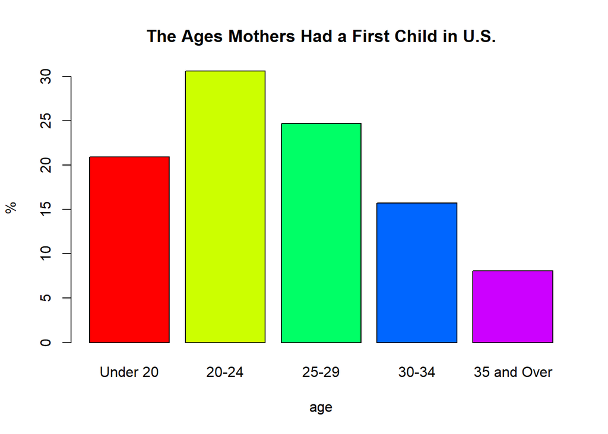

```r
rsho=c(20.9,30.6,24.7,15.7,8.1)
names(rsho)=c("Under 20","20-24","25-29","30-34","35 and Over")
barplot(rsho, main="The Ages Mothers Had a First Child in U.S.", col=rainbow(5),
        legend = rownames(rsho),xlab="age",ylab="%")
```

### b.

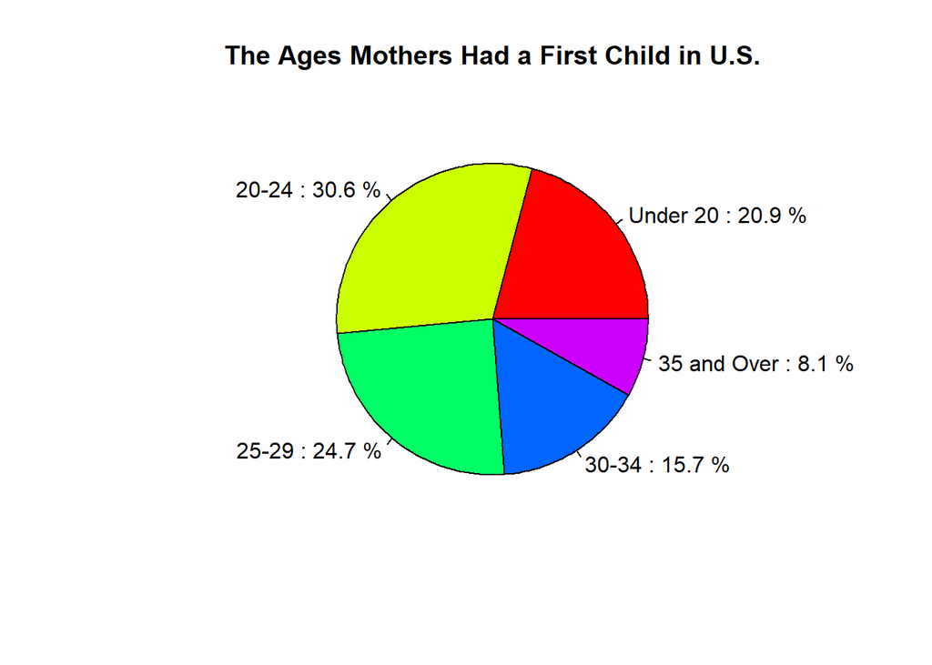

```r
lb=paste(names(rsho),":",rsho,"%")
pie(rsho,labels=lb,main="The Ages Mothers Had a First Child in U.S.", col=rainbow(5))
```

### c.

### Ans: 圓餅圖比較適合傳達「百分比」資料；長條圖較適合傳達「總數」資料，故此題圓餅圖呈現較合適，但以長條圖呈現也沒有絕對不可。

### **Exercise 2.46**

### a.

```r
mu=c(220,20,50,450,300,30,20,50,200,35,25,50,250,100,0,100,20,13,200,2,125,150,90,60)
stem(mu)
```

```
  The decimal point is 2 digit(s) to the right of the |

  0 | 00122233455569
  1 | 0035
  2 | 0025
  3 | 0
  4 | 5
```

### b.

#### 註：此直方圖以20為一區間，包含下界，不包含上界

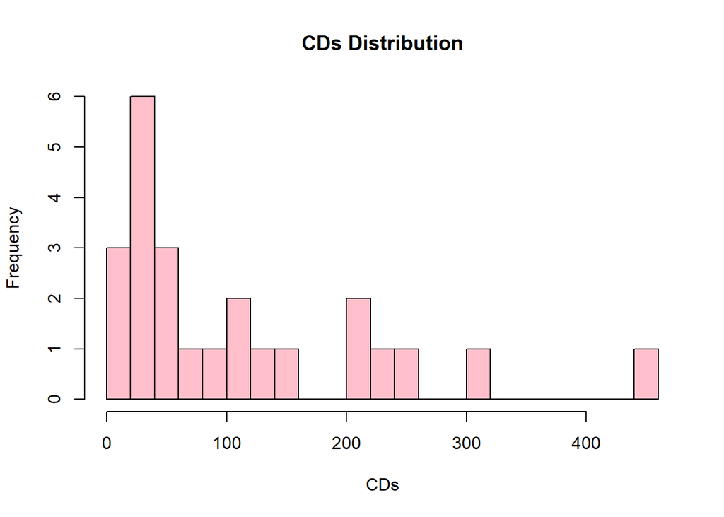

```r
mu=c(220,20,50,450,300,30,20,50,200,35,25,50,250,100,0,100,20,13,200,2,125,150,90,60)
hist(mu,breaks=20,main='CDs Distribution',xlab="CDs",col="pink",right=F)
```

### c.

### Ans: 根據直方圖所呈現，最高的次數出現在20~40之間，且次數由低到高呈現「遞減」的趨勢

### **Exercise 2.52**

### a.

#### 註：此直方圖以5為一區間，包含下界，不包含上界

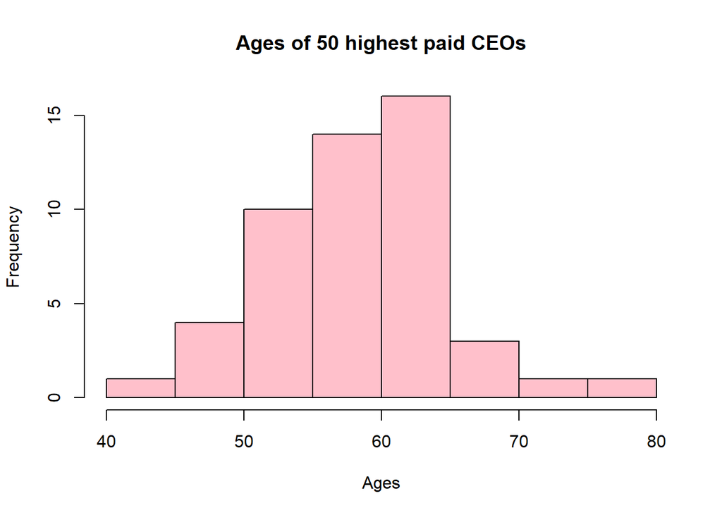

```r
ceo=c(42,47,48,49,49,50,50,50,50,51,51,51,52,54,54,55,55,55,55,56,57,57,57,57,57,58,58,59,59,60,60,60,61,61,62,62,62,62,62,63,63,64,64,64,64,67,67,69,74,78)
hist(ceo,breaks=10,main='Ages of 50 highest paid CEOs',xlab="Ages",col="pink",right=F)
```

### b.

```r
stem(ceo,scale=0.5)
```

```
  The decimal point is 1 digit(s) to the right of the |

  4 | 27899
  5 | 000011124455556777778899
  6 | 0001122222334444779
  7 | 48
```

### c.

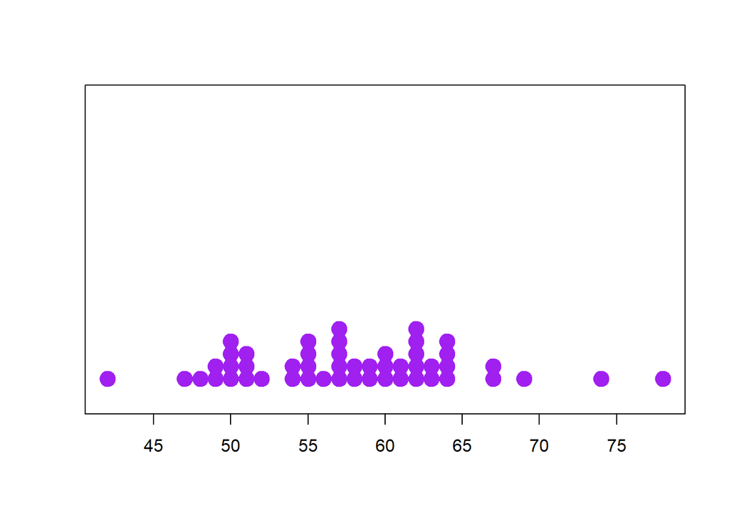

```r
stripchart(ceo, method = "stack", offset = .3, at = .15, pch = 19,cex=2,col="purple")
```

### d.

### Ans: 從直方圖來看比較符合鐘形（常態分布），出現最多的次數偏中間，約為55~65歲，愈往兩旁愈是減少。

### e.

### Ans: Yes. 78 is the one outlier.

```r
#library(outliers)
#outlier(ceo)
upper=summary(ceo)[5]+1.5*IQR(ceo)
lower=summary(ceo)[2]-1.5*IQR(ceo)
length(ceo[ceo>upper | ceo<lower])>0
```

```
[1] TRUE
```

### f.

### Ans: 可能薪資比較會出現極端值，因為不同公司CEO的薪資落差好像有點大；年紀也是有可能，不過因為大部分都是集中在中年，所以就比較少出現。

### **Exercise 2.66**

### a.

```r
blo=c(110,123,132,150,127,118,102,122)
summary(blo)[3]
```

```
Median
 122.5
```

### b.

```r
summary(blo)[2]
```

```
1st Qu.
    116
```

```r
summary(blo)[5]
```

```
3rd Qu.
 128.25
```

### c.

```r
IQR(blo)
```

```
[1] 12.25
```

### d.

```r
upper2=summary(blo)[5]+1.5*IQR(blo)
lower2=summary(blo)[2]-1.5*IQR(blo)
blo[blo>upper2 | blo<lower2]
```

```
[1] 150
```

### e,

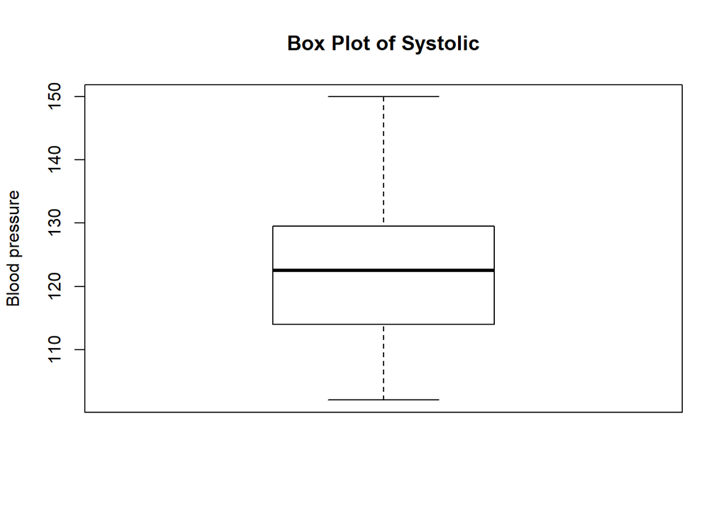

```r
boxplot(blo,ylab="Blood pressure",main="Box Plot of Systolic")
```

### **Exercise 2.76**

### a.

```r
g1=c(2,30,35,70,100,120,135,150,190,200)
summary(g1)
```

```
   Min. 1st Qu.  Median    Mean 3rd Qu.    Max.
   2.00   43.75  110.00  103.20  146.25  200.00
```

### b.

```r
g2=c(8,12,16,29,35,40,45,46,95)
summary(g2)
```

```
   Min. 1st Qu.  Median    Mean 3rd Qu.    Max.
   8.00   16.00   35.00   36.22   45.00   95.00
```

### c.

```r
rg=c(max(g1)-min(g1),max(g2)-min(g2))
names(rg)=c("Group1","Group2")
rg
```

```
Group1 Group2
   198     87
```

### d.

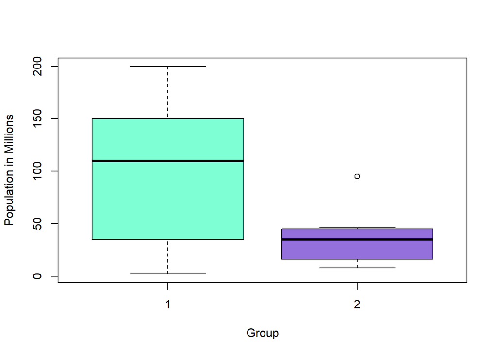

```r
boxplot(g1,g2,col=c("aquamarine","mediumpurple"),xlab="Group",ylab="Population in Millions",names=c("1","2"))
```

### **Exercise 2.96**

### Ans: 5。若成績為常態分布，標準差為5，平均是70，代表約有95%的情況成績會落在60到80之間，能考到80分以上只有2.5%的情況，相對較難；而若標準差是15，約有68%情況成績會落在55到85分之間，考到80分並非特別困難。

### **Exercise 2.104**

```r
me=56 #平均值
sd=2 #標準差
```

### a.

```r
me-2*sd
```

```
[1] 52
```

### b.

```r
me+2*sd
```

```
[1] 60
```

### c.

```r
me+sd
```

```
[1] 58
```

## *R Practice*

```r
MyOutlierDetect=function(arg1,arg2){
  Student=read.csv('Student.csv')
  if (arg1=='GPA'){
    upper3=summary(Student$GPA)[5]+1.5*IQR(Student$GPA, na.rm = T)
    lower3=summary(Student$GPA)[2]-1.5*IQR(Student$GPA, na.rm = T)
    if (arg2>upper3 | arg2<lower3) {
      return("YES")
    }else{
      return("NO")
    }
  }else if(arg1=='MissClass'){
    upper3=summary(Student$MissClass)[5]+1.5*IQR(Student$MissClass, na.rm = T)
    lower3=summary(Student$MissClass)[2]-1.5*IQR(Student$MissClass, na.rm = T)
    if (arg2>upper3 | arg2<lower3) {
      return("YES")
    }else{
      return("NO")
    }
  }else if(arg1=='PartyDays'){
    upper3=summary(Student$PartyDays)[5]+1.5*IQR(Student$PartyDays, na.rm = T)
    lower3=summary(Student$PartyDays)[2]-1.5*IQR(Student$PartyDays, na.rm = T)
    if (arg2>upper3 | arg2<lower3) {
      return("YES")
    }else{
      return("NO")
    }
  }else if(arg1=='StudyHrs'){
    upper3=summary(Student$StudyHrs)[5]+1.5*IQR(Student$StudyHrs, na.rm = T)
    lower3=summary(Student$StudyHrs)[2]-1.5*IQR(Student$StudyHrs, na.rm = T)
    if (arg2>upper3 | arg2<lower3) {
      return("YES")
    }else{
      return("NO")
    }
  }
}
MyOutlierDetect('GPA' , 2)
```

```
[1] "YES"
```

```r
MyOutlierDetect('GPA' , 3.2)
```

```
[1] "NO"
```

```r
MyOutlierDetect('MissClass' , 3)
```

```
[1] "YES"
```

```r
MyOutlierDetect('MissClass' , 1)
```

```
[1] "NO"
```

```r
MyOutlierDetect('PartyDays' , 25)
```

```
[1] "YES"
```

```r
MyOutlierDetect('PartyDays' , 5)
```

```
[1] "NO"
```

```r
MyOutlierDetect('StudyHrs' , 50)
```

```
[1] "YES"
```

```r
MyOutlierDetect('StudyHrs' , 20)
```

```
[1] "NO"
```